# Linear Algebra - Vectors

Harsha Achyuthuni

26/10/2020

## Topics covered

1. Basics of Vectors
2. Subspaces and spans
3. Linear independence of vectors
4. Basis, Norms, inner products and their properties

## Basics of vectors

Consider two vectors a and b

```r
a <- c(1,2)
b <- c(1,1)
```

The two vectors can be visualised in a 2D coordinate system as follows:

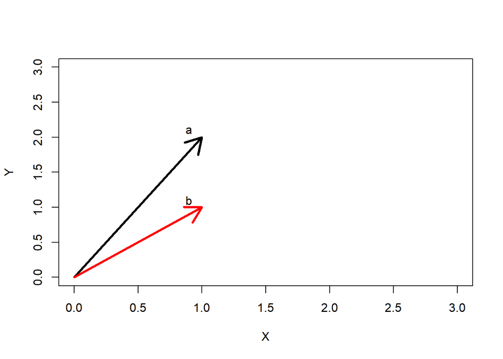

We can perform two types of linear operations on these vectors:  
1. Vector addition  
2. Multiplication of the vector with a scalar

Vector addition:  
If we add a and b together, the sum would be a vector whose members are the sum of the corresponding members from a and b.

```r
a+b
```

```
## [1] 2 3
```

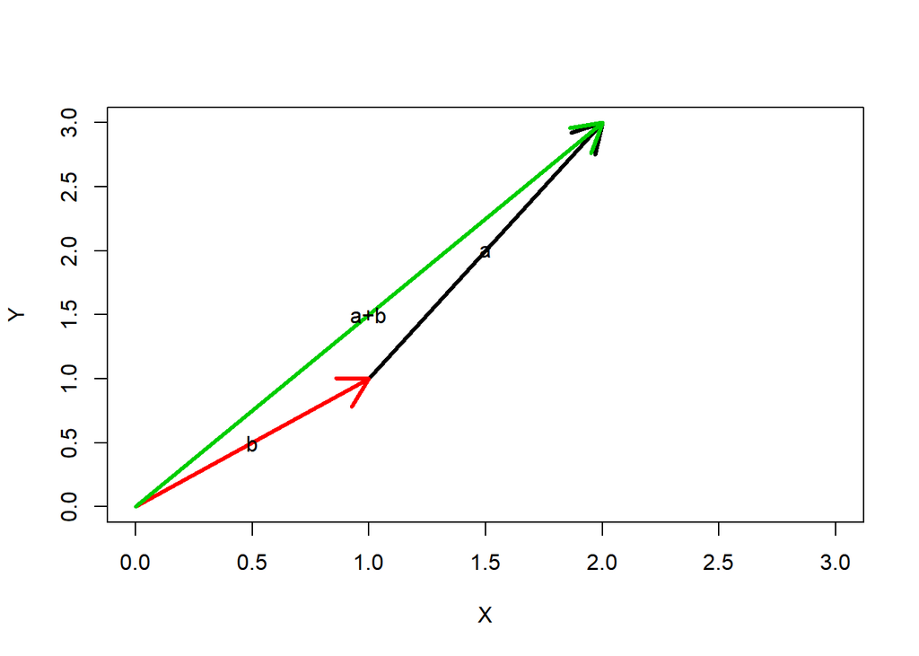

Vector multiplication: If we multiply b by 2, we will get a vector with each of its members multiplied by 2.

```r
2*b
```

```
## [1] 2 2
```

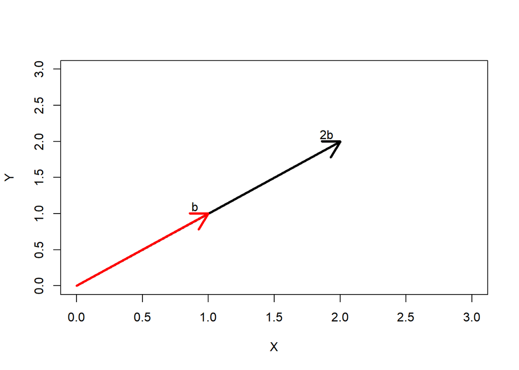

## Subspaces and span

As we can perform only two kinds of linear operations on the vectors, any linear combinations will be of the form:
$$S= \alpha a + \beta b$$
Where $\alpha$ and $\beta$ are real numbers and $a$ and $b$ are vectors.

What about all possible linear combinations of $a$ and $b$?

The linear combination of the vector a and b form the entire 2D plane.

Vector space is the space in which the vector can exist. A 2D vector, like a or b, will have vector space of $R^2$ and a 3D vector like d=[1,2,3] is in the vector space $R^3$.  
Span: The set of all possible linear combinations of vectors is called the span of those set of vectors.

For the above two vectors a = [1,2] and b=[1,1], the entire 2d space is the span, as we can get every vector in the 2d space as a linear combination of the two vectors.

To explain the difference between vector space and vector span, consider the two vectors d=[1,2,3] and e=[1,1,1] As the two vectors are in 3 dimensions, they have a vector space of 3 or $R^3$.  
Adding d+e I get another vector in 3d.

```r
d <- c(1,2,3)
e <- c(1,1,1)
d+e
```

```
## [1] 2 3 4
```

But what are all the linear combinations for d and e?

This forms a 2d plane which goes thru the origin. Therefore these vectors span a plane (in $R^2$) although their vector space is ($R^3$).

The maximum span that any set of vectors can have is equal to their vector space.

## Linear Independence

Linear independence is when one vector has no relationship with another. In the first example with a=[1,2] and b=[1,1], any vectors in the 2d space can be written as a linear combination of a and b. In the second example with d=[1,2,3] and e=[1,1,1], any vector on the plane can be written as a linear combination of d and e. A vector which is not in the plane, like f = [2,3,3] is linearly independent of d and e, as no $\alpha$ and $\beta$ satisfy $f=\alpha d+\beta e$.

In a vector space of *n* dimensions (vector space is n), there can be at max n vectors which are linearly independent.

## Bases, norms and inner products

A basis for $R^n$ space is any linearly independent set of vectors S such that span(S) = n.  
From the above examples, a and b are in the vector space $R^2$ and also have their span as $R^2$. Therefore they form a basis for $R^2$.  
Similarly, the three independent vectors d, e and f are in the vector space $R^3$ and form a basis for $R^3$.

The standard basis for $R^2$ is [1.0] and [0,1].

The norm of the vector is the length of the vector.

$$l_2 \,norm(\bar{v}) = \sqrt{x_1^2 + y_1^2+..}$$

```r
norm(a,  type="2")
```

```
## [1] 2.236068
```

```r
norm(d,  type="2")
```

```
## [1] 3.741657
```

The dot product (or inner product) takes two vectors as an input and returns a number as an output. It is defined as $\bar{x}.\bar{y} = \sum{x_i\times y_i}$. It represents the length of the shadow of one vector on the other.

```r
library(geometry)
dot(a,b)
```

```
## [1] 3
```

In the next post in this series, I will talk about matrices.

References: 1. [Strang, G. (2016). Introduction to Linear Algebra. Wellesley-Cambridge Press](http://math.mit.edu/~gs/linearalgebra/)